← bristle impact scenes

# Do the dimorphic targets group the contact chemosensory bristle types?

## The question

Which dimorphic neurons take the drive of each bristle type?

Do the dimorphic targets put the bristle types into blocks?

Does a block agree with the receptor assignment of the laboratory?

The bristle impact page measures how much drive each bristle type sends to the dimorphic neurons. This page uses the same numbers for a different question. It shows which dimorphic neurons take that drive.

Related pages: the ascending ranking and the AN09B017 scenes. The AN09B017 page shows the receptor assignment table. This page tests that table.

```r
options(rgl.useNULL = TRUE)   # must precede any library that pulls rgl in (nat)

suppressMessages({
  library(neuprintr); library(malecns); library(nat)
  library(coconatfly); library(coconat); library(Matrix)
  options(malecns.dataset = "male-cns:v1.0")   # malecns helpers ignore MCNS_DATASET
  library(dplyr); library(tibble)
  library(ggplot2); library(ggrepel); library(scales); library(patchwork)
})

R_DIR <- "/Users/fkampf/Documents/pheromone.paper/analyses/an_investigation/R"

Sys.setenv(AN_CASE = "an05b023bc")   # only for the palettes
source(file.path(R_DIR, "_paths.R"))
source(file.path(R_DIR, "_an_pair.R"))
source(file.path(R_DIR, "_bristle_impact.R"))
source(file.path(R_DIR, "_bristle_typing.R"))
source(file.path(R_DIR, "_bristle_typing_layers.R"))
neuprint_login(server = MCNS_SERVER, dataset = MCNS_DATASET)
```

```r
load_once <- function(name, expr, envir = .GlobalEnv) {
  # eval() here evaluates a quote()d expression written literally in this file -
  # a lazy-evaluation idiom for "only fetch if not already cached", not a parser
  # of external input.
  if (!exists(name, envir = envir, inherits = FALSE)) {
    assign(name, eval(expr), envir = envir)
  }
  get(name, envir = envir)
}

mba  <- load_once("mba", quote(mcns_body_annotations()))
pool <- sensory_pool(mba)
```

## The unit

The bristle impact page explains the unit in full. This page repeats it in one paragraph and does not derive it again.

One synapse count becomes a fraction. The page divides every edge by the whole input of the cell that receives it. It then adds these fractions over the cells of a dimorphic type. One entry gives the input as a count of complete dimorphic cells.

## The measure

Each bristle type has a profile. The profile holds one number for each dimorphic type. That number is the drive over the one hop route, in the unit above.

The page then compares two bristle types by the cosine of their two profiles. The cosine is 1 when two bristle types send their drive to the same targets in the same proportions. The cosine is 0 when two bristle types share no target.

The page does not centre the profiles. Every value is a share and no share is negative. A centred correlation would invent a negative similarity.

```r
ed     <- load_once("ed", quote(bristle_impact_edges(mba, pool, vol = "whole")))
groups <- pool_group_cells(mba, pool, by = "type")
mm     <- bristle_impact_matrices(ed, groups)
ts     <- typing_similarity(mm, mba, route = "one_hop", min_drive = BT_MIN_DRIVE,
                            cells = groups)

ts$drive
```

| type | eff | n_targets | cells |
| --- | --- | --- | --- |
| LgLG4 | 0.07952522 | 303 | 42 |
| LgLG8 | 2.89023445 | 363 | 14 |
| LgLG7 | 1.75171846 | 319 | 21 |
| LgLG5 | 3.44432283 | 390 | 13 |
| LgLG6 | 5.50559618 | 386 | 16 |
| LgLG3 | 0.91382645 | 408 | 162 |
| WG2 | 0.43286294 | 375 | 97 |
| LgLG2 | 1.33705235 | 387 | 129 |
| WG1 | 1.18999086 | 371 | 96 |
| WG3 | 0.90002084 | 388 | 96 |

[output cut: 3 more lines]

The interneuron layer keeps 1129 of 1885 interneurons at `min_frac` 0.005. The dimorphism annotation covers 468 dimorphic types, and 436 of them take drive from the bristles.

A bristle type needs a drive of 0.05 complete dimorphic cells to enter the figures. The cut removes 2 bristle types: SNxxxx at 0.021, on 7 cells, SNch05 at 0.017, on 8 cells. These rows have almost no drive. A row of that size still gives a high cosine, and that cosine is not a measurement. 13 bristle types remain.

## The receptor assignment under test

```r
asg_all <- receptor_assignment(mba, types = sort(unique(unname(groups))))
asg     <- ts$assign

m_set <- as.character(asg$type[asg$group == "M cells"])
f_set <- as.character(asg$type[asg$group == "F cells"])
b_set <- as.character(asg$type[asg$group == "both"])

asg_all
```

|  | type | receptor_type | group |
| --- | --- | --- | --- |
| 1 | LgLG1a | putative_ppk23 | M cells |
| 2 | LgLG1b | putative_ppk25 | F cells |
| 3 | LgLG2 | putative_IR52b | both |
| 4 | LgLG3 | NA | not assigned |
| 5 | LgLG4 | NA | not assigned |
| 6 | LgLG5 | putative_ppk25 | F cells |
| 7 | LgLG6 | putative_ppk23 | M cells |
| 8 | LgLG7 | putative_ppk23 | M cells |
| 9 | LgLG8 | putative_ppk25 | F cells |
| 10 | SNch05 | NA | not assigned |

[output cut: 5 more lines]

The laboratory has a receptor label for some bristle types. The page reads the label from the `receptor_type` annotation, and it does not retype the table. The figures therefore follow the annotation, and not a copy of the annotation.

The assignment labels 10 of the 13 bristle types on this page. The types with the label M cells are LgLG7, LgLG6, WG4, LgLG1a. The types with the label F cells are LgLG8, LgLG5, WG3, LgLG1b. The types with the third label are LgLG2, WG1, and the assignment calls them responsive to both sexes.

The label M cells means the cell of a bristle that detects the male pheromone. The label F cells means the cell of a bristle that detects the female pheromone. This page tests these two labels against the dimorphic targets.

One record of the same table does differ from the annotation. The hardcoded table in `03_neuroglancer_scenes.R` lists LgAG1 with the third label. The annotation has no receptor label for LgAG1, and the pool holds 0 LgAG1 cells.

**The laboratory takes part of the receptor assignment from downstream partners. An agreement is therefore weak evidence, and a disagreement is more informative.**

## Bristle type against bristle type

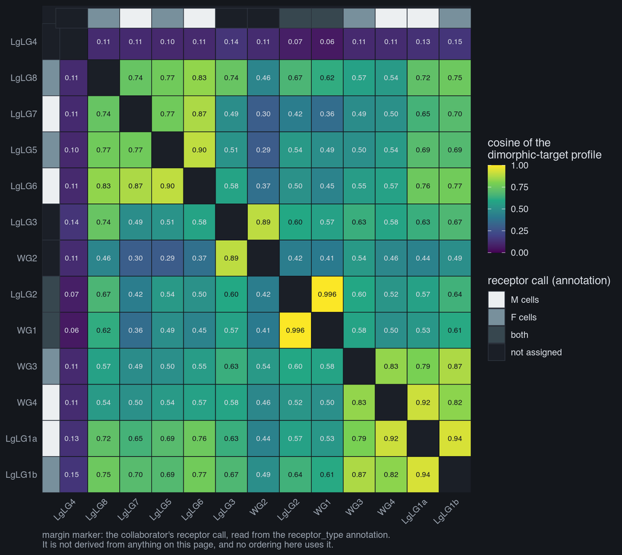

```r
typing_matrix_plot(ts)
```

The rows and the columns come from ward.D2 linkage on 1 minus the cosine. **The order comes from the data, and not from the receptor assignment.** The strips at the margin show the assignment, and the reader can compare the two. The leaf order is LgLG4, LgLG8, LgLG7, LgLG5, LgLG6, LgLG3, WG2, LgLG2, WG1, WG3, WG4, LgLG1a, LgLG1b. One tree has many leaf orders, so read the blocks and not the order.

A cosine of non-negative profiles is never less than zero. One value alone is therefore not readable. The median off the diagonal of this matrix is 0.56. The full scale of this measure is in the section “What a cosine of that size is worth”.

**The measure does not separate the M cells from the F cells.** LgLG1a has the label M cells and LgLG1b has the label F cells. Their cosine is 0.94. LgLG1a and WG4 give 0.92. LgLG1b and WG3 give 0.87. WG3 and WG4 give 0.83.

The largest cosine of the whole matrix is 0.996, between WG1 and LgLG2. LgLG2 and WG1 have the third label, and not the label M cells or the label F cells.

LgLG1a, LgLG1b, WG3 and WG4 make one block at one hop. The six cosines inside that block are 0.79 to 0.94. LgLG5, LgLG6, LgLG7 and LgLG8 make a second block. The 16 cosines between the two blocks are 0.49 to 0.77. 0 of these 16 values are as large as the smallest cosine inside the first block.

LgLG2 and WG1 stay outside both blocks. Their cosines to LgLG1a, LgLG1b, WG3 and WG4 are 0.50 to 0.64. LgLG4 is an outlier. Its cosines to the other bristle types are 0.06 to 0.15.

**A failure to separate is not a proof of identity. Two channels can meet on the same targets one hop downstream and still be two channels.**

## The tree, and how firm it is

```r
bt_groups <- list(
  `LgLG1a LgLG1b WG3 WG4`   = quad,
  `LgLG5 LgLG6 LgLG7 LgLG8` = five,
  `LgLG2 WG1`               = c("LgLG2", "WG1"),
  `assignment M set`        = m_set,
  `assignment F set`        = f_set)

boot <- typing_bootstrap(ts$m, B = 500, groups = bt_groups)
boot
```

| kind | label | members | support | n_boot |
| --- | --- | --- | --- | --- |
| clade | LgLG1a LgLG1b WG3 WG4 | LgLG1a, LgLG1b, WG3, WG4 | 0.990 | 500 |
| clade | LgLG5 LgLG6 LgLG7 LgLG8 | LgLG5, LgLG6, LgLG7, LgLG8 | 0.904 | 500 |
| clade | LgLG2 WG1 | LgLG2, WG1 | 1.000 | 500 |
| clade | assignment M set | LgLG7, LgLG6, WG4, LgLG1a | 0.000 | 500 |
| clade | assignment F set | LgLG8, LgLG5, WG3, LgLG1b | 0.000 | 500 |
| top pair | top pair is LgLG2/WG1 | LgLG2, WG1 | 1.000 | 500 |
| top pair | top pair is LgLG1a/LgLG1b | LgLG1a, LgLG1b | 0.000 | 500 |

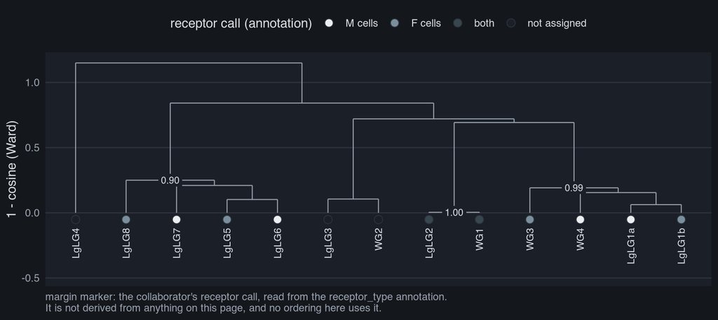

```r
typing_tree_plot(ts, support = boot)
```

The block LgLG1a, LgLG1b, WG3 and WG4 has support 0.99. The block LgLG5, LgLG6, LgLG7 and LgLG8 has support 0.90. The pair LgLG2 and WG1 has support 1.00.

The pair with the largest cosine is LgLG2, WG1 in 1.00 of the draws. It is LgLG1a, LgLG1b in 0.00 of the draws.

The two sets of the receptor assignment do not appear. The M set is a block in 0 of 500 draws. The F set is a block in 0 of 500 draws.

**LgLG5, LgLG6, LgLG7 and LgLG8 make one block. The receptor assignment splits these four types between M cells and F cells.**

## What a cosine of that size is worth

```r
N_SHUFFLE <- 200

# min_frac and rows: the interneuron cut and the drive cut of the main measure,
# applied to the control as well, so the two numbers compare
inp <- interneuron_profiles(ed, groups, min_frac = mm$min_frac,
                            rows = rownames(ts$m))
nl  <- typing_null(ts$m, B = N_SHUFFLE, extra = list(`first synapse` = inp))
bl  <- typing_baseline(ts$m)
```

This section adds two controls and one further test. They give the scale of a cosine on this measure.

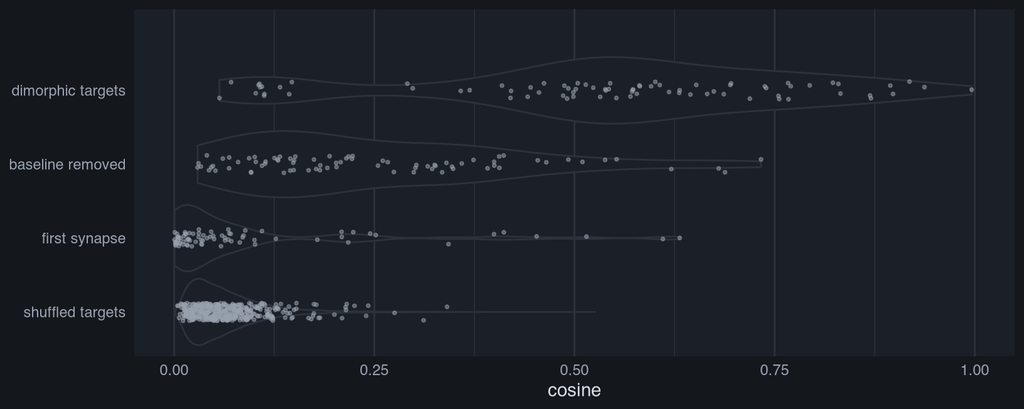

```r
typing_null_plot(nl, baseline = bl)
```

The first control shuffles each bristle type’s values across the target labels. It repeats the shuffle 200 times. The shuffle keeps every value and destroys only the alignment. The shuffled cosines have a median of 0.05 and a 95th percentile of 0.15. The observed cosines have a median of 0.56. The alignment is real.

The second control keeps the same bristle types and changes the target set. Its columns are the 1129 interneurons that take bristle synapses and also reach a dimorphic cell. The interneuron cut at `min_frac` 0.005 applies to these columns and to the main measure. The drive cut applies to both as well, so the two measures use the same 13 bristle types.

The median of this control is 0.03 and the maximum is 0.63. LgLG1a and LgLG1b give 0.51 at the first synapse. LgLG2 and WG1 give 0.40. The bristle types are not alike at the first synapse. This control counts one synapse, and the main measure counts two.

The largest LgLG4 cosine is 0.15. The 95th percentile of the shuffled control is 0.15. LgLG4 has a drive of 0.080 complete dimorphic cells, above the cut at 0.05. A profile of that size gives a noisy cosine. This result is a failure to measure LgLG4. It is not a proof that LgLG4 has no channel of its own.

The page also removes the shared baseline. It divides each target column by the mean over the bristle types, and it computes the cosine again. The median off the diagonal changes from 0.56 to 0.20. The Spearman correlation between the two sets of values off the diagonal is 0.819.

The largest pair after this step is WG1 and LgLG2 at 0.73. LgLG1a and LgLG1b give 0.68. That value is larger than LgLG1a and WG4 at 0.54, and larger than LgLG1b and WG3 at 0.55. The similarity is not only a shared drive onto one large target.

## Where the drive goes

```r
tt  <- target_table(ts, n_top = BT_TOP_TARGETS, keep_row_max = TRUE)
ord <- sort(colSums(ts$m), decreasing = TRUE)

row_max <- stats::setNames(colnames(ts$m)[apply(ts$m, 1, which.max)], rownames(ts$m))
forced  <- setdiff(unique(row_max), names(ord)[seq_len(BT_TOP_TARGETS)])

# what the cosine would be if it saw only the columns this figure shows
kept_cols <- setdiff(as.character(tt$cols), "rest")
S_cut     <- cosine_matrix(ts$m[, kept_cols, drop = FALSE])
S_cut     <- S_cut[rownames(ts$S), colnames(ts$S)]
cut_move  <- max(abs(S_cut - ts$S), na.rm = TRUE)

forced
```

```
## [1] "DNde007"   "AN05B102d"
```

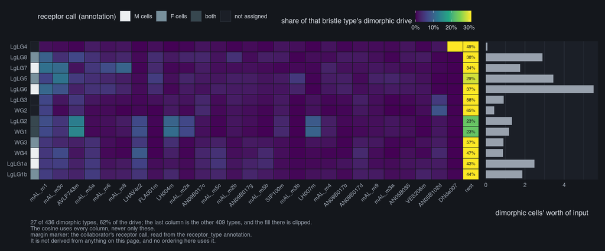

```r
target_heatmap(tt, ts)
```

The figure shows 27 dimorphic types. They take 61.9 percent of the modelled drive. The last column holds the other 409 types together, so the cut is visible inside the figure. Per bristle type that column is 0.23 to 0.65.

The figure shows the 25 largest columns, and the row rule adds 2 more. The cut of the figure is therefore not the boundary at rank 25. At that boundary the column totals are 0.29 and 0.28, a difference of 0.009.

The table also adds the largest target of each bristle type, whatever its rank. This adds DNde007, AN05B102d. Without that rule the LgLG4 row is empty. The reader then does not see the one bristle type that behaves differently.

The largest partners follow the two blocks. LgLG6 sends most to mAL_m1 at 0.57, then mAL_m3c at 0.44. LgLG5 sends most to mAL_m3c at 0.41, then mAL_m1 at 0.21. LgLG1a sends most to LHAV4c2 at 0.15. LgLG2 sends most to AVLP743m at 0.18, and WG1 sends most to AVLP743m at 0.17. The two types have the same largest target, and the bristle types with that largest target are LgLG2, WG1.

## The mAL targets, part one

```r
mt <- mal_table(ts)

mw <- with(mt$long, tapply(share, list(as.character(type), as.character(mal)), sum))
mw[is.na(mw)] <- 0
l1 <- function(a, b) sum(abs(mw[a, ] - mw[b, ]))
ms <- function(tp, ml) f2(mt$long$share[mt$long$type == tp & mt$long$mal == ml])
mf <- function(tp)     f2(mt$frac$mal_frac[mt$frac$type == tp])

m2a_other <- sort(mw[setdiff(rownames(mw), c("LgLG2", "WG1")), "mAL_m2a"],
                  decreasing = TRUE)
quad_l1   <- utils::combn(quad, 2, function(p) l1(p[1], p[2]))
```

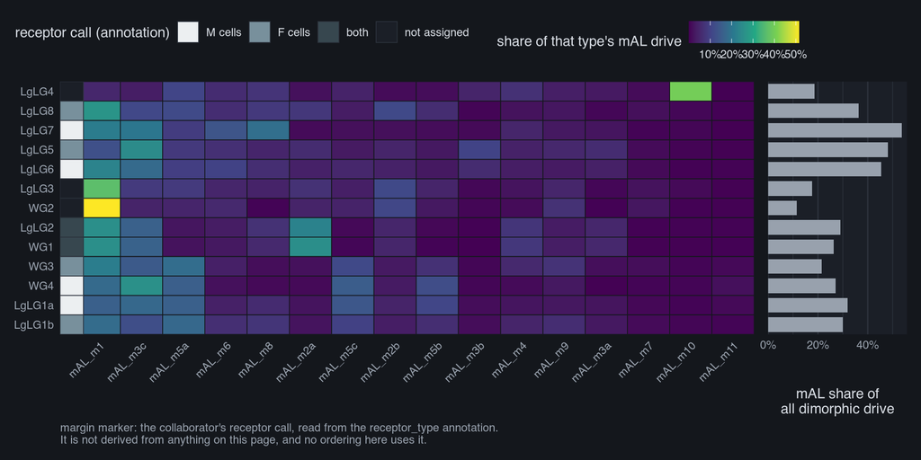

```r
mal_heatmap(mt, ts)
```

The mAL types take 37.4 percent of all drive over the one hop route. They are 16 subtypes. Every row in the figure adds up to 1, so the figure shows a preference and not a size. The right column shows the mAL share of the whole dimorphic drive of that bristle type.

LgLG2 and WG1 send 0.23 and 0.25 of their mAL drive to mAL_m2a. The largest share on mAL_m2a among the other bristle types is LgLG8 at 0.08. WG2 and LgLG3 send 0.51 and 0.36 to mAL_m1. The mAL share of the whole dimorphic drive is 0.45 for LgLG6 and 0.29 for LgLG2.

LgLG1a, LgLG1b, WG3 and WG4 have similar mAL profiles. The six distances among these four types are 0.23 to 0.52, on the sum of the absolute differences. LgLG2 against LgLG1a gives 0.82 on the same measure. The next figure tests whether anything separates the four types inside the targets that they share.

## The mAL targets, part two: the test

```r
mc <- mal_contrast(ts)
mc$stats
```

| contrast | facet | pearson | spearman | n_same_sign | n | pearson_clr |
| --- | --- | --- | --- | --- | --- | --- |
| receptor split | receptor split\n(LgLG1a - LgLG1b) vs (WG4 - WG3) | 0.9343585 | 0.9500000 | 16 | 16 | 0.7428455 |
| cross | cross\n(LgLG1a - WG3) vs (WG4 - LgLG1b) | 0.3607882 | 0.2911765 | 10 | 16 | -0.1196081 |
| leg vs wing | leg vs wing\n(LgLG1a - WG4) vs (LgLG1b - WG3) | 0.7579646 | 0.8588235 | 12 | 16 | 0.7279846 |

Four types make exactly three ways to build two pairs. The figure shows all three, because one pairing alone would be a selection.

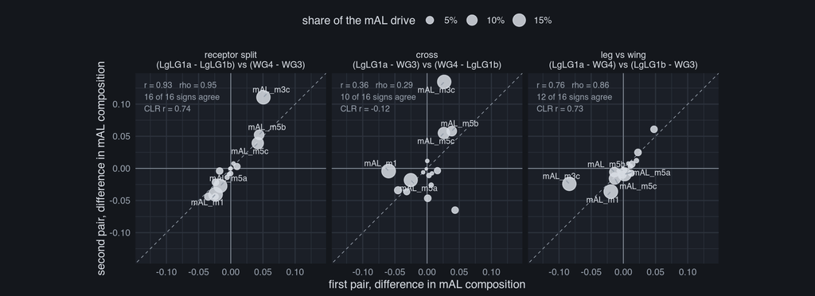

```r
mal_contrast_plot(mc)
```

The receptor split compares LgLG1a minus LgLG1b with WG4 minus WG3. The two differences have the same sign on 16 of 16 mAL subtypes. The Pearson correlation is 0.93 and the Spearman correlation is 0.95.

The leg against wing pairing gives 0.76 on 12 of 16 subtypes. The cross pairing gives 0.36 on 10 of 16 subtypes. The three pairings use the same four bristle types and the same subtypes. The three values are therefore not independent, and the page compares their sizes only.

The 16 shares of one row add up to one. This alone can force an agreement. The centred log-ratio transform reduces that effect. The transform first adds 1.2^{-4} to every share, because 0 shares are zero and a zero has no logarithm. After the transform the receptor split gives 0.74, leg against wing gives 0.73, and the cross pairing gives -0.12.

Read this result with care. Three limits apply to it. First, the page compares two pairs, so the agreement is one observation. It is not a test on 16 degrees of freedom. Second, the 16 shares of one row add up to one, and that alone can force an agreement. Third, the difference between the four types is small.

The distance between LgLG1a and LgLG1b in mAL composition is 0.30. Between LgLG2 and LgLG1a it is 0.82.

Read the result in this way. The whole profile does not separate these four types. A failure to separate is not a proof of one channel. Two axes exist inside the mAL targets that the four types share. One axis follows the receptor assignment and one axis follows the leg against the wing. After the transform the two axes give 0.74 and 0.73.

## Does the mAL axis reach further

```r
ax <- typing_axis_scores(ts, contrast = "receptor split")
ax
```

| type | score | group | in_axis |
| --- | --- | --- | --- |
| WG4 | 0.163718663 | M cells | TRUE |
| LgLG1a | 0.091435978 | M cells | TRUE |
| LgLG5 | 0.071407005 | F cells | FALSE |
| WG3 | 0.011598873 | F cells | TRUE |
| LgLG6 | 0.007486461 | M cells | FALSE |
| LgLG1b | -0.005846170 | F cells | TRUE |
| LgLG7 | -0.006954404 | M cells | FALSE |
| LgLG8 | -0.025643070 | F cells | FALSE |
| LgLG2 | -0.025754958 | both | FALSE |
| WG1 | -0.026167955 | both | FALSE |

[output cut: 3 more lines]

The axis is the mean of the two pair differences. The page then projects every bristle type onto it.

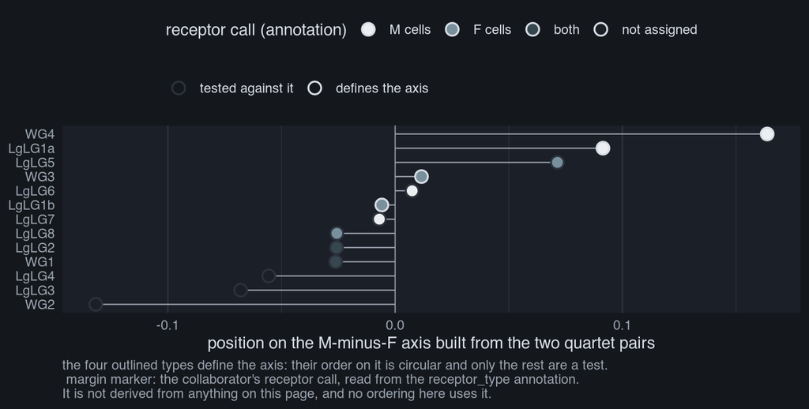

```r
typing_axis_plot(ax)
```

The four types of the receptor split define the axis. Their order on the axis is therefore not a test, and the figure marks them. Only LgLG5, LgLG6, LgLG7 and LgLG8 are a test.

The receptor label does not order those four types. LgLG5 has the label F cells and a score of 0.071. LgLG8 has the label F cells and a score of -0.026. LgLG6 has the label M cells and a score of 0.007. LgLG7 has the label M cells and a score of -0.007.

## The male-specific share

```r
dsh <- dimorph_share_table(ts, ed$dimtab)
ms_tab <- dsh |> filter(dimorphism == "male-specific") |> arrange(desc(share))
ms_tab
```

| type | dimorphism | eff | share |
| --- | --- | --- | --- |
| LgLG5 | male-specific | 3.22887699 | 0.9374490 |
| LgLG7 | male-specific | 1.62714130 | 0.9288829 |
| LgLG6 | male-specific | 5.02138706 | 0.9120515 |
| LgLG8 | male-specific | 2.58424065 | 0.8941284 |
| LgLG2 | male-specific | 1.10204861 | 0.8242374 |
| WG1 | male-specific | 0.94828307 | 0.7968826 |
| LgLG1b | male-specific | 1.45928351 | 0.7819134 |
| LgLG1a | male-specific | 1.91773462 | 0.7735510 |
| LgLG3 | male-specific | 0.62053991 | 0.6790566 |
| WG3 | male-specific | 0.60039800 | 0.6670934 |

[output cut: 3 more lines]

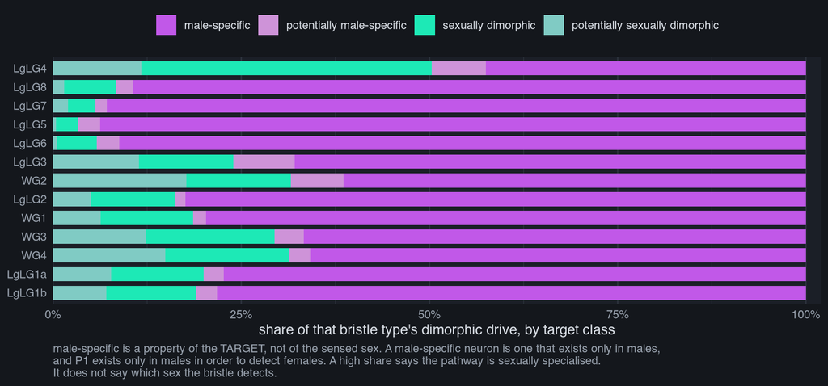

```r
dimorph_share_plot(dsh)
```

**The term male-specific is a property of the target, and not a property of the sensed sex.** A male-specific neuron is a neuron that exists only in males. P1 exists only in males, and P1 detects females. A high male-specific share shows that the pathway is sexually specialised. It does not show which sex the bristle detects. Do not read this figure as a sex label.

LgLG5 has the highest male-specific share at 0.94. LgLG7 follows at 0.93, and LgLG6 follows at 0.91. LgLG4 has the lowest share at 0.43. The rows keep the order of the first figure, so the reader can compare the two figures.

## The same measure in three volumes

```r
tv <- typing_volumes(mba, pool)

vts <- function(key) {
  if (!is.null(tv$ts[[key]])) tv$ts[[key]] else tv$ts[[unname(IMPACT_VOLS[key])]]
}
cvol <- function(a, b, v) {
  x <- tv$long$cosine[tv$long$vol == v & tv$long$type_a == a & tv$long$type_b == b]
  cv(x[1])
}

# the order of the three named pairs in one volume, largest first, read from the
# table and not written down in the prose
P3   <- c("LgLG1a / LgLG1b", "LgLG1b / WG3", "LgLG1a / WG4")
ord3 <- function(v) {
  d <- tv$pairs |> filter(vol == v, pair %in% P3, !is.na(cosine))
  paste(as.character(d$pair[order(d$cosine, decreasing = TRUE)]), collapse = ", ")
}
```

```r
w_long <- tv$long |> filter(vol == "whole reconstruction", !is.na(cosine))
b_long <- tv$long |> filter(vol == "brain", !is.na(cosine))
j_vol  <- inner_join(w_long, b_long, by = c("type_a", "type_b"),
                     suffix = c("_w", "_b"))

r_wb <- cor(j_vol$cosine_w, j_vol$cosine_b)
d_wb <- mean(abs(j_vol$cosine_w - j_vol$cosine_b))
c(r = r_wb, mean_abs_diff = d_wb)
```

```
##             r mean_abs_diff
##     0.8659422     0.1203814
```

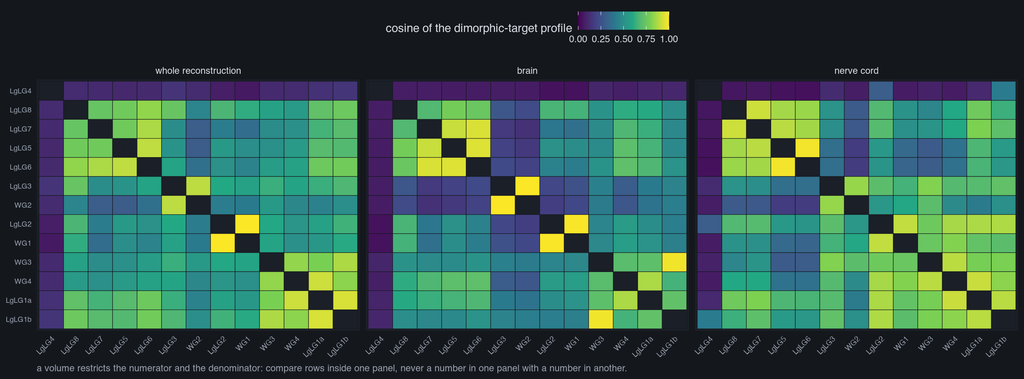

```r
typing_volume_plot(tv)
```

The three panels share one row order and one colour scale. The whole reconstruction is the default everywhere else on this page.

A volume restricts the numerator and the denominator. In the brain the denominator counts only the input synapses inside the brain. One synapse is therefore a larger share of that denominator. This is a property of the definition, and the figure does not show it.

The whole reconstruction and the brain give similar cosines. The correlation off the diagonal is 0.87. The mean absolute difference is 0.12.

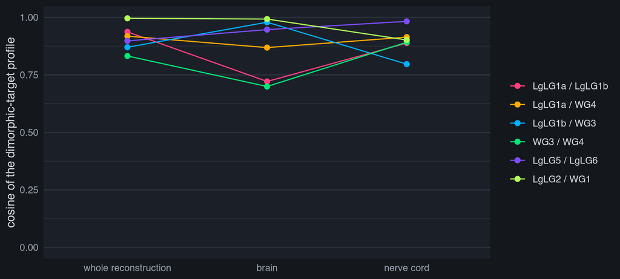

```r
typing_pair_plot(tv)
```

The brain changes the order of three pairs. LgLG1a and LgLG1b give 0.94 in the whole reconstruction and 0.72 in the brain. LgLG1b and WG3 give 0.87 and 0.98. LgLG1a and WG4 give 0.92 and 0.87.

The figure shows six pairs, and these three are three of them. In the whole reconstruction the order of the three, from the largest, is LgLG1a / LgLG1b, LgLG1a / WG4, LgLG1b / WG3. In the brain the order is LgLG1b / WG3, LgLG1a / WG4, LgLG1a / LgLG1b. The two pairs of the receptor assignment are LgLG1a / WG4 and LgLG1b / WG3.

The change is a re-weighting of one measure and not a second measurement. It is one comparison, on one volume, and it applies to the four types under test. Follow it up, and do not report it as a result.

## The direct route

```r
ts_dir <- typing_similarity(mm, mba, route = "direct", min_drive = BT_MIN_DRIVE,
                            cells = groups)

dir_targets <- colnames(ts_dir$m)[colSums(ts_dir$m) > 0]
dir_asc     <- mba |>
  filter(type %in% dir_targets, superclass == "ascending_neuron") |>
  distinct(type) |> nrow()
dtop <- sort(colSums(ts_dir$m), decreasing = TRUE)[1:3]

tt_dir <- target_table(ts_dir, n_top = length(dir_targets), keep_row_max = TRUE)
dtop
```

```
## AN05B102c  ANXXX151 AN05B102d
##  1.604277  1.394758  1.241331
```

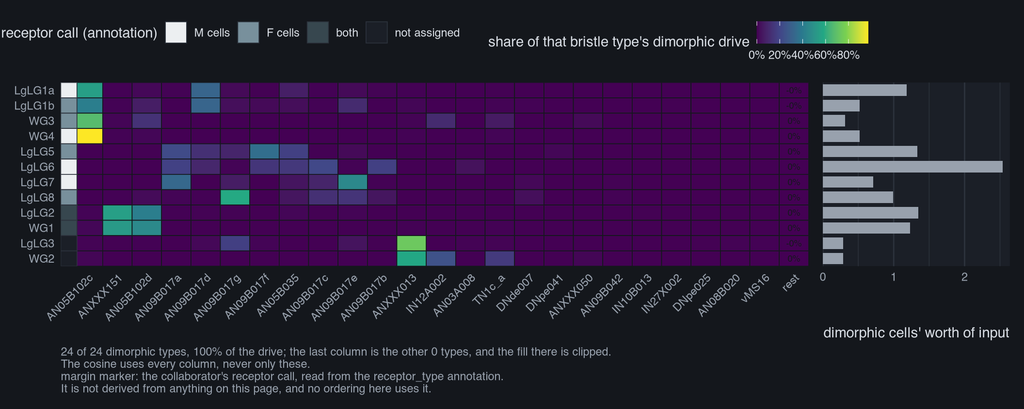

```r
target_heatmap(tt_dir, ts_dir)
```

The direct route is one synapse. The bristles reach 24 dimorphic types this way, and 17 of them are ascending neurons. That target set is different in kind from the one hop set. That difference is the reason to show it. The three largest are AN05B102c at 1.60, ANXXX151 at 1.39 and AN05B102d at 1.24. These types also appear on the AN09B017 page.

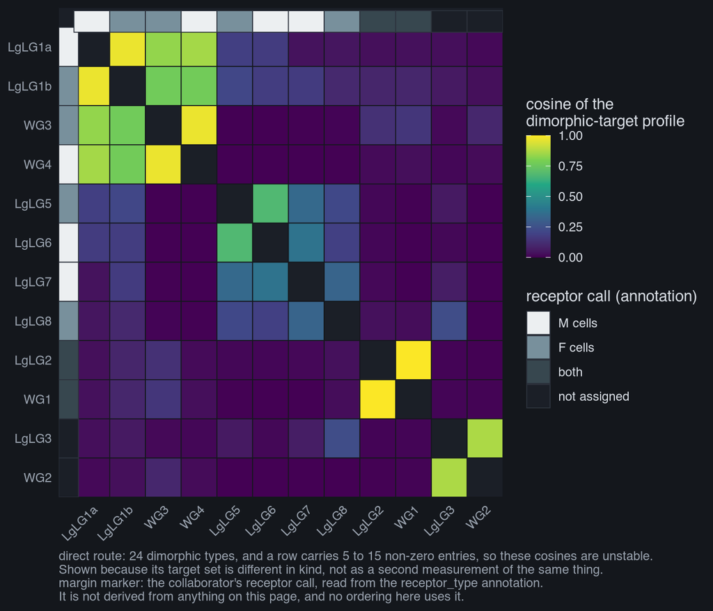

```r
typing_direct_plot(ts_dir)
```

Read the direct cosines with care. They use 24 columns, against 436 columns for the one hop measure. A row also holds few values above zero. The same drive cut applies here. It keeps 12 bristle types, and it removes LgLG4, SNxxxx, SNch05. The page argues about LgLG4 above, and these two figures do not show it.

The direct route is also the smaller part of the modelled drive. This is not a second measurement of the same thing.

## Do the blocks come from the neuromere

```r
MIN_SEG_CELLS <- 10

# segment_similarity(), and never cosine_matrix(mm_seg$one_hop): that route
# skips BT_MIN_DRIVE, which this page applies to every row, and it skips the
# sort that pins the leaf order against the row order of mba.
sg     <- segment_groups(mba, pool, min_cells = MIN_SEG_CELLS)
mm_seg <- bristle_impact_matrices(ed, sg)
seg    <- segment_similarity(mm_seg, route = "one_hop", min_drive = BT_MIN_DRIVE)
S2     <- seg$S
wb     <- typing_within_between(S2)
wb
```

| type | n_groups | within_type | same_segment_other | delta |
| --- | --- | --- | --- | --- |
| LgLG2 | 3 | 0.9593574 | 0.6082873 | 0.35107015 |
| LgLG3 | 3 | 0.8469348 | 0.6259126 | 0.22102216 |
| LgLG1a | 3 | 0.8618132 | 0.7080237 | 0.15378956 |
| LgLG1b | 3 | 0.8459884 | 0.7531363 | 0.09285213 |
| LgLG5 | 1 | NA | 0.7548760 | NA |
| LgLG6 | 1 | NA | 0.8070799 | NA |
| LgLG7 | 1 | NA | 0.7298162 | NA |
| LgLG8 | 1 | NA | 0.7958160 | NA |
| WG1 | 1 | NA | 0.4953053 | NA |
| WG2 | 1 | NA | 0.4699608 | NA |

[output cut: 2 more lines]

The leg types have cells in T1, T2 and T3. The wing types all enter through one nerve. Every block could therefore be an effect of the neuromere and not of the bristle type. This section crosses the two keys.

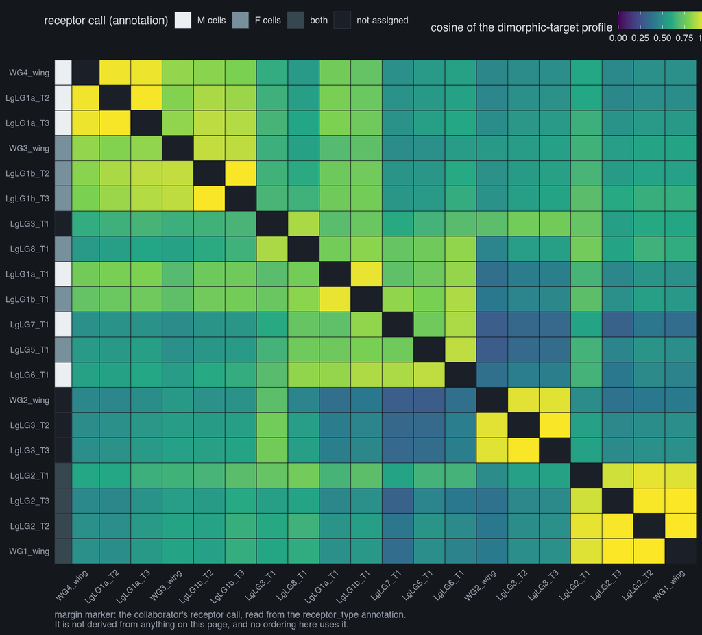

```r
typing_segment_plot(S2, asg)
```

The figure holds 20 rows. One row is one bristle type in one neuromere, and each row holds at least 10 cells. The drive cut of 0.05 complete dimorphic cells applies here too, and it removes 3 rows.

A within-type value needs a bristle type with cells in more than one neuromere. 4 of the 12 types in the figure meet that condition. For 4 of these 4 types the within-type mean is larger than the same-neuromere mean. For LgLG2 the two means are 0.96 and 0.61. For LgLG1a they are 0.86 and 0.71. For LgLG1b they are 0.85 and 0.75.

One exception is worth a report. LgLG1a_T1 and LgLG1b_T1 give 0.96 with each other. Against the T1 rows of the second block LgLG1a_T1 gives LgLG5_T1 at 0.76, LgLG6_T1 at 0.84, LgLG7_T1 at 0.72, LgLG8_T1 at 0.78. LgLG1b_T1 gives LgLG5_T1 at 0.79, LgLG6_T1 at 0.87, LgLG7_T1 at 0.83, LgLG8_T1 at 0.82. LgLG1a_T1 gives 0.79 to its own T2 row, and LgLG1b_T1 gives 0.77 to its own T2 row. The page reports this exception and does not explain it.

## The layer above

```r
# an_bristle_edges(), an_bristle_matrix() and exact_split_test() run in the
# section "Bristle type against bristle type", because the two sides of this
# split give that section the names of its two blocks. This section reports the
# test itself.
sp$tab
```

[output not shown]

[output not shown]

| members_a | members_b | segregation | rank | is_assignment |
| --- | --- | --- | --- | --- |
| LgLG1a, LgLG1b, WG3, WG4 | LgLG5, LgLG6, LgLG7, LgLG8 | 0.9700236 | 1 | FALSE |
| LgLG1a, LgLG1b, LgLG7, WG4 | LgLG5, LgLG6, LgLG8, WG3 | 0.7886192 | 2 | FALSE |
| LgLG1a, LgLG1b, LgLG8, WG4 | LgLG5, LgLG6, LgLG7, WG3 | 0.7853792 | 3 | FALSE |
| LgLG1a, LgLG7, WG3, WG4 | LgLG1b, LgLG5, LgLG6, LgLG8 | 0.7819655 | 4 | FALSE |
| LgLG1a, LgLG8, WG3, WG4 | LgLG1b, LgLG5, LgLG6, LgLG7 | 0.7815225 | 5 | FALSE |
| LgLG1a, LgLG1b, LgLG6, WG4 | LgLG5, LgLG7, LgLG8, WG3 | 0.7799416 | 6 | FALSE |
| LgLG1a, LgLG1b, LgLG5, WG4 | LgLG6, LgLG7, LgLG8, WG3 | 0.7768233 | 7 | FALSE |
| LgLG1a, LgLG6, WG3, WG4 | LgLG1b, LgLG5, LgLG7, LgLG8 | 0.7729665 | 8 | FALSE |
| LgLG1a, LgLG5, WG3, WG4 | LgLG1b, LgLG6, LgLG7, LgLG8 | 0.7707950 | 9 | FALSE |
| LgLG1a, LgLG1b, LgLG7, WG3 | LgLG5, LgLG6, LgLG8, WG4 | 0.7688406 | 10 | FALSE |

[output cut: 25 more lines]

The earlier sections measure the dimorphic targets. This section measures the ascending neurons, which are one synapse from the bristles. The unit here is a count of synapses from a bristle type onto an ascending type.

The measure is a segregation value. A split puts the bristle types into two sides. For one ascending type the measure keeps the larger of its two side counts. It adds that over the ascending types, and it divides by all the synapses. A value of 0.5 shows no separation, and a value of 1 shows complete separation.

The measure uses the 38 ascending types of 135 with at least 200 bristle synapses. Those types take 97.2 percent of the bristle synapses. 8 bristle types carry the label M cells or the label F cells. There are 35 ways to divide those types into two groups of four. The page measures all of them, so this is an exact test.

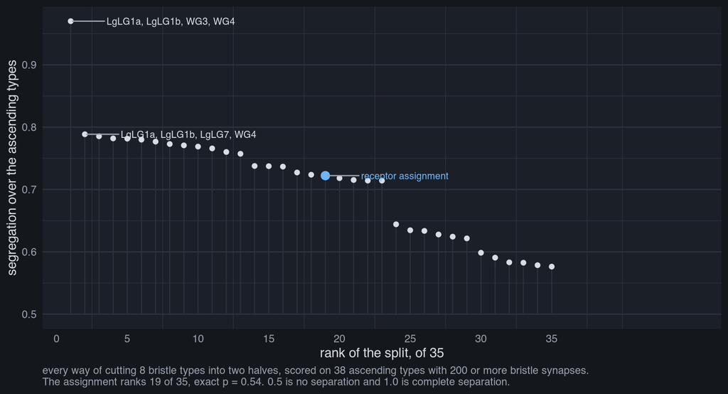

```r
exact_split_plot(sp)
```

The best split is LgLG1a, LgLG1b, WG3, WG4 against LgLG5, LgLG6, LgLG7, LgLG8 at 0.970. The second best is LgLG1a, LgLG1b, LgLG7, WG4 against LgLG5, LgLG6, LgLG8, WG3 at 0.789. The difference between the two is 0.18. The whole range of the 35 values is 0.576 to 0.970.

The receptor split gives 0.722. Its rank is 19 of 35. The exact p value is 0.54. That p value is the share of the 35 enumerated splits that reach 0.722 or pass it.

**The ascending layer separates the bristle types. It does not separate them on the receptor split.**

The two sides of the best split give the first two groups of this page. Group I is LgLG1a, LgLG1b, WG3, WG4. Group II is LgLG5, LgLG6, LgLG7, LgLG8. LgLG2, WG1 carry the third label, so this test does not use them. The page calls them Group III.

```r
grp_asc  <- list(`Group I` = quad, `Group II` = five)
ns       <- nested_split_test(ab, groups = grp_asc, sets = sets)
pairs_in <- ns$tab
cr       <- ns$carriers

pairs_in
```

| group | members_a | members_b | segregation | is_assignment | min_syn | n_kept | n_all | rank |
| --- | --- | --- | --- | --- | --- | --- | --- | --- |
| Group I | LgLG1a, WG4 | LgLG1b, WG3 | 0.7273299 | TRUE | 50 | 56 | 129 | 1 |
| Group I | LgLG1a, LgLG1b | WG3, WG4 | 0.6303646 | FALSE | 50 | 56 | 129 | 2 |
| Group I | LgLG1a, WG3 | LgLG1b, WG4 | 0.5749355 | FALSE | 50 | 56 | 129 | 3 |
| Group II | LgLG5, LgLG6 | LgLG7, LgLG8 | 0.8833857 | FALSE | 50 | 19 | 54 | 1 |
| Group II | LgLG5, LgLG8 | LgLG6, LgLG7 | 0.7218330 | TRUE | 50 | 19 | 54 | 2 |
| Group II | LgLG5, LgLG7 | LgLG6, LgLG8 | 0.7029878 | FALSE | 50 | 19 | 54 | 3 |

Four types make exactly three ways to build two pairs. The page measures all three inside each group, because one pairing alone would be a selection. The receptor split is one of the three.

**This test compares three pairings, so the best of three is not a significant result.** One pairing of the three must come first. A p value from three values cannot go below one third. The page therefore gives the three segregation values, their order, and no p value.

The cut inside a group is 50 bristle synapses. A group of four holds a part of the synapses that all eight types hold. **Do not compare a value of this test with a value of the test above.**

In Group I the best pairing is LgLG1a, WG4 against LgLG1b, WG3 at 0.727. The other two give 0.630 and 0.575. **The best pairing of Group I is the receptor split.**

In Group II the best pairing is LgLG5, LgLG6 against LgLG7, LgLG8 at 0.883. The receptor split gives 0.722. **The best pairing of Group II crosses the receptor split.**

Read both results as an order of three values. A win over two alternatives is not a test of significance.

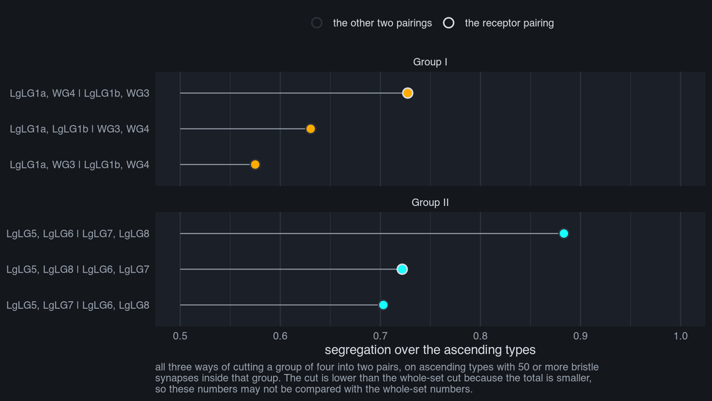

```r
nested_split_plot(ns)
```

The index of an ascending type is its M count minus its F count. The page divides that difference by the sum of the two counts. The counts are the four bristle types of one group, so an index belongs to one group and not to the whole set.

Two ascending types make the split of Group I. AN05B023b takes 6781 synapses from LgLG1a and 4346 from WG4. It takes 561 from LgLG1b and 398 from WG3. Its index is +0.84. AN05B023c has the opposite preference, and its index is -0.86.

AN05B102a takes all four types of Group I in a similar measure: 8017 from LgLG1a, 5354 from LgLG1b, 5701 from WG3 and 8138 from WG4. The separation is a property of AN05B023b and AN05B023c. It is not a property of the whole layer.

Three ascending types make the best pairing of Group II. AN05B035 takes 1478 synapses from LgLG6 and 934 from LgLG5. It takes 163 from LgLG8 and 116 from LgLG7. AN09B017f takes 701 from LgLG5 and 539 from LgLG6. It takes 0 from LgLG7 and 0 from LgLG8. AN09B017e makes the same split in the other direction. It takes 550 from LgLG7 and 226 from LgLG8, against 44 from LgLG5 and 20 from LgLG6.

Two ascending types of Group II do follow the receptor split. The index of AN09B017b is +0.82 and the index of AN09B017g is -0.84. The next section names those two types again.

## Which ascending neuron matches the vAB3 profile

```r
vp <- ascending_layer_table(mba, an_types = rownames(asc$m))
vp
```

| an_type | cells | in_T1 | in_T2 | in_T3 | in_vnc | in_brain | in_leg | pT1 | pT2 | pT3 | p_brain | out_total | out_mAL | pct_mAL | out_pC1 | pct_pC1 | out_LC1 | pct_LC1 |
| --- | --- | --- | --- | --- | --- | --- | --- | --- | --- | --- | --- | --- | --- | --- | --- | --- | --- | --- |
| AN09B017a | 2 | 1555 | 10 | 0 | 1641 | 323 | 1565 | 99.3610224 | 0.6389776 | 0.00000000 | 16.4460285 | 6075 | 4456 | 73.34979424 | 0 | 0.00000000 | 0 | 0.00000000 |
| AN09B017b | 2 | 2407 | 0 | 0 | 2558 | 1722 | 2407 | 100.0000000 | 0.0000000 | 0.00000000 | 40.2336449 | 11229 | 4921 | 43.82402707 | 384 | 3.41971680 | 38 | 0.33840948 |
| AN09B017d | 2 | 3282 | 0 | 0 | 3438 | 977 | 3282 | 100.0000000 | 0.0000000 | 0.00000000 | 22.1291053 | 9767 | 3228 | 33.05006655 | 132 | 1.35148971 | 191 | 1.95556466 |
| AN09B017f | 2 | 1610 | 0 | 0 | 1674 | 1319 | 1610 | 100.0000000 | 0.0000000 | 0.00000000 | 44.0694955 | 9845 | 3179 | 32.29050279 | 673 | 6.83595734 | 711 | 7.22194007 |
| AN09B017g | 2 | 3924 | 0 | 0 | 4008 | 903 | 3924 | 100.0000000 | 0.0000000 | 0.00000000 | 18.3872938 | 14883 | 4616 | 31.01525230 | 482 | 3.23859437 | 839 | 5.63730431 |
| AN09B017e | 2 | 1804 | 0 | 1 | 1884 | 1453 | 1805 | 99.9445983 | 0.0000000 | 0.05540166 | 43.5421037 | 12481 | 3838 | 30.75074113 | 167 | 1.33803381 | 108 | 0.86531528 |
| AN05B035 | 2 | 4525 | 31 | 10 | 4829 | 2959 | 4566 | 99.1020587 | 0.6789312 | 0.21901007 | 37.9943503 | 6931 | 1534 | 22.13244842 | 0 | 0.00000000 | 0 | 0.00000000 |
| AN05B102c | 2 | 1385 | 3342 | 3658 | 14915 | 1535 | 8385 | 16.5175909 | 39.8568873 | 43.62552177 | 9.3313070 | 13019 | 1395 | 10.71510869 | 101 | 0.77578923 | 62 | 0.47622705 |
| AN09B017c | 2 | 1705 | 0 | 0 | 1820 | 576 | 1705 | 100.0000000 | 0.0000000 | 0.00000000 | 24.0400668 | 7628 | 811 | 10.63188254 | 387 | 5.07341374 | 41 | 0.53749345 |
| AN05B023c | 2 | 1114 | 1828 | 2841 | 8785 | 304 | 5783 | 19.2633581 | 31.6098911 | 49.12675082 | 3.3447024 | 9742 | 606 | 6.22048861 | 16 | 0.16423732 | 91 | 0.93409977 |

[output cut: 28 more lines]

The table holds the same 38 ascending types as the test above. The literature names one ascending neuron vAB3 (Kallman BR, Kim H, Scott K, 2015, eLife 4:e11188, PMID 26568316). The paper gives it three properties. The input is in the front leg neuromere. The output goes onto mAL. The output also goes onto pC1. The page tests those three properties on the table above.

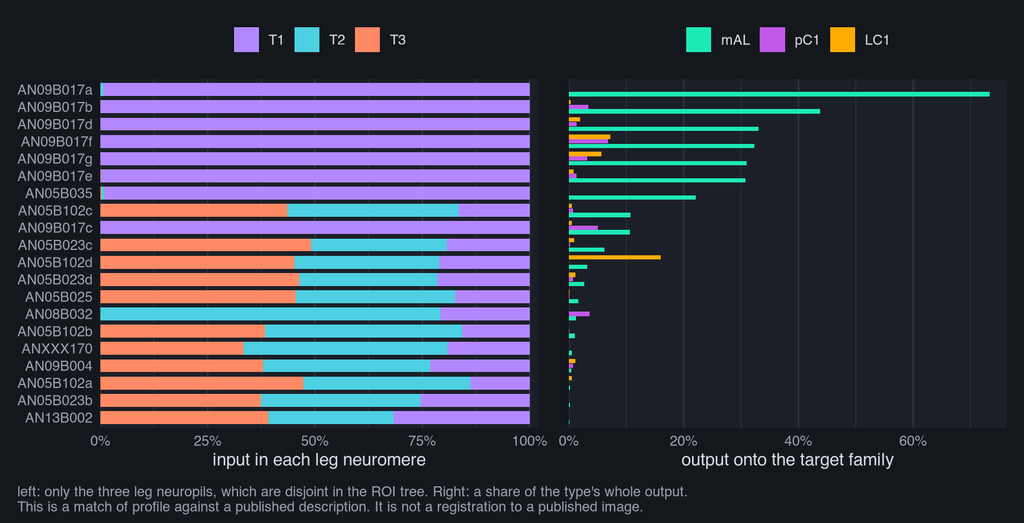

```r
ascending_layer_plot(vp)
```

The 7 AN09B017 types take 99.4 to 100.0 percent of their leg neuropil input in T1. The largest mAL output of the table is AN09B017a at 73.35 percent of its output. The largest pC1 output is AN09B017f at 6.84 percent. Both types are AN09B017 types.

AN05B023 and AN05B102 are different. Their T1 share is 13.7 to 30.0 percent, and the rest of their input is in T2 and in T3. Their largest pC1 output is 0.78 percent.

**AN09B017 matches the three properties of vAB3. AN05B023 and AN05B102 do not match them.**

This is a match of a profile, and it is not an identification. The page does not register a skeleton onto a published image. A profile match gives a name to test. The page does not call AN09B017 vAB3.

## Where the two streams meet

```r
cvg <- target_input_table(mba, types = names(ord)[1], label = names(ord)[1])
cvg$tab
```

| in_type | w | in_class | pct | rank |
| --- | --- | --- | --- | --- |
| AN09B017b | 2647 | NA | 10.686745529 | 1 |
| AN09B017a | 1492 | NA | 6.023658606 | 2 |
| AN09B017g | 1398 | NA | 5.644151964 | 3 |
| PVLP206m | 1256 | NA | 5.070854697 | 4 |
| LHAV4c2 | 1212 | NA | 4.893213291 | 5 |
| AN09B017e | 1183 | NA | 4.776131455 | 6 |
| mAL_m1 | 1063 | NA | 4.291654891 | 7 |
| SIP101m | 1055 | NA | 4.259356454 | 8 |
| SIP103m | 853 | NA | 3.443820905 | 9 |
| AVLP722m | 742 | NA | 2.995680084 | 10 |

[output cut: 466 more lines]

The largest dimorphic target of this page is mAL_m1 at 1.84 complete dimorphic cells. This section measures where its input comes from.

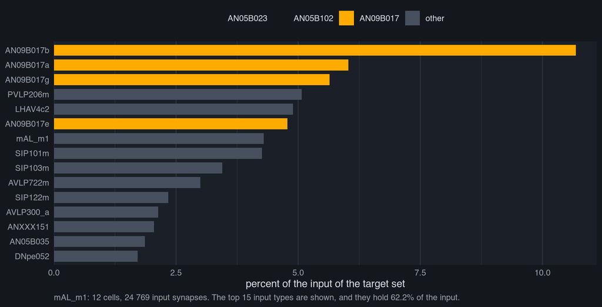

```r
input_share_plot(cvg)
```

mAL_m1 takes 24769 input synapses in all. It takes 10.69 percent of them from AN09B017b. It takes 6.02 percent from AN09B017a and 5.64 percent from AN09B017g.

AN09B017b has an index of +0.82 and AN09B017g has an index of -0.84. The two types are on opposite sides of the receptor split inside Group II. mAL_m1 takes both of them.

The page then tests the receptor split on the whole target profile.

```r
mf_lab <- stats::setNames(rep(c("M cells", "F cells"),
                             c(length(m_set), length(f_set))),
                          c(m_set, f_set))
pg <- class_gap_test(ts$S, mf_lab)

c(same = pg$same_mean, different = pg$diff_mean, gap = pg$gap, p = pg$p)
```

```
##       same  different        gap          p
##  0.7014504  0.7264774 -0.0250270  0.6550400
```

The test keeps the cosine matrix of the first figure. It shuffles the two labels over the 8 labelled bristle types, and it uses 50000 shuffles.

The mean cosine inside a class is 0.701 over 12 pairs. The mean cosine between the two classes is 0.726 over 16 pairs. The gap is -0.025 and the p value is 0.66.

**The receptor split does not order the target profiles. The gap is -0.025 and the p value is 0.66.**

**A failure to separate is not a proof that the two streams carry the same information.** The page states that rule in the section “Bristle type against bristle type”, and this result does not change it.

The convergence is a measurement. It is not a proof that the two streams carry the same information. One target cell can take two inputs on two branches. One input can also arrive through an inhibitory interneuron. This page adds the two paths together, and it cannot see the sign of either one.

## The third group and the cVA node

```r
lc1 <- lc1_types(mba)
lin <- target_input_table(mba, types = lc1, label = "LC1")
asp <- target_input_table(mba, types = "LHAV4c2", label = "LHAV4c2")

# one table per LC1 type as well: the three types are one set above, and the
# prose below asks what each of them takes on its own
lin_by <- lapply(stats::setNames(lc1, lc1),
                 function(tp) target_input_table(mba, types = tp, label = tp))

# WHICH ASCENDING TYPES REACH LC1, and which of those carry Group II.
#
# A GROUP II CARRIER IS A THRESHOLD ON A MEASUREMENT, and not a list of names. It
# is an ascending type that takes more than half of its bristle synapses in the
# layer 1 matrix from the four Group II types. The carrier table of
# nested_split_test() is the wrong set here: it holds every ascending type above
# the nested cut, and that includes AN05B102d, whose Group II share is 0.18.
asc_all <- sort(unique(ascending_bodies(mba)$an_type), method = "radix")
g2_share   <- rowSums(asc$m[, five, drop = FALSE]) / rowSums(asc$m)
g2_carrier <- names(g2_share)[g2_share > 0.5]

lin_asc <- lin$tab[lin$tab$in_type %in% asc_all, ]
lin_g2  <- lin_asc[lin_asc$in_type %in% g2_carrier, ]

lc1
```

```
## [1] "AVLP743m" "LH004m"   "LH007m"
```

```r
lin$tab
```

| in_type | w | in_class | pct | rank |
| --- | --- | --- | --- | --- |
| DA1_lPN | 3110 | ALPN | 10.182032478 | 1 |
| M_lvPNm45 | 1704 | ALPN | 5.578837087 | 2 |
| AN05B102d | 1592 | NA | 5.212152960 | 3 |
| LHPV4a1 | 1097 | NA | 3.591540073 | 4 |
| SIP101m | 950 | NA | 3.110267156 | 5 |
| AN09B017g | 839 | NA | 2.746856993 | 6 |
| AN09B017f | 711 | NA | 2.327789419 | 7 |
| AN01A089 | 661 | NA | 2.164091147 | 8 |
| AN09B004 | 554 | NA | 1.813776847 | 9 |
| M_vPNml63 | 519 | ALPN | 1.699188057 | 10 |

[output cut: 834 more lines]

3 types carry the LC1 synonym in the annotation. They are AVLP743m, LH004m, LH007m. The page reads the identity from the annotation, and it does not retype it. All 3 types are male-specific, and all 3 are in one hemilineage.

LC1 comes from Ruta V, Datta SR, Vasconcelos ML, Freeland J, Looger LL, Axel R, 2010, Nature 468:686-690, PMID 21124455. The paper names LC1 as the cVA recipient cluster of the lateral horn. That name and those numbers come from the paper.

The 3 types hold 25 cells. They take 30544 input synapses together. The largest single input type is DA1_lPN at 10.18 percent. DA1 is the cVA glomerulus and DA1_lPN is its projection neuron. The olfactory projection neurons together give 26.37 percent of the input.

LC1 also takes input from the ascending neurons. The largest ascending input is AN05B102d at 5.21 percent. That type is the carrier of the Group III arm.

The layer 1 matrix holds the 8 labelled bristle types. A Group II carrier takes more than half of those synapses from the four Group II types. 5 Group II carriers give input to LC1. The two largest are AN09B017g at 2.75 percent and AN09B017f at 2.33 percent.

**LC1 is a shared target. Group II reaches LC1, and Group III is not alone on it.**

LH007m takes 16.33 percent of its input from DA1_lPN and 4.52 percent from AN05B102d. LH004m takes 6.71 percent from AN05B102d and 6.49 percent from DA1_lPN.

LHAV4c2 carries the aSP8 synonym in the annotation. Its DA1 input is 0.05 percent. **LC1 and aSP8 are not one group at type resolution.**

```r
mal_cols <- grep("^mAL_", colnames(ts$m), value = TRUE)

lr <- arm_drive_table(ts$m, arms = list(LC1 = lc1, mAL = mal_cols),
                      groups = grp3)
cm <- carrier_matrices(ed, mba, pool)

# n_top holds the whole attribution, so the two shares below divide by the whole
# path weight and not by the weight of the ten largest carriers. The figures and
# the prose show the first rows only.
N_CARRIERS <- 10000
pc_lc1 <- carrier_weights(cm, bristles = b_set, targets = lc1,
                          n_top = N_CARRIERS)
pc_mal <- carrier_weights(cm, bristles = c("LgLG5", "LgLG6"), targets = mal_cols,
                          n_top = N_CARRIERS)
stopifnot(nrow(pc_lc1) < N_CARRIERS, nrow(pc_mal) < N_CARRIERS)

lc1_top <- pc_lc1$weight[1] / sum(pc_lc1$weight)
mal_fam <- sum(pc_mal$weight[grepl("^AN09B017", pc_mal$mid_type)]) /
           sum(pc_mal$weight)

head(pc_lc1, 5)
```

| mid_type | weight | rank |
| --- | --- | --- |
| AN05B102d | 0.7114844627 | 1 |
| ANXXX151 | 0.1265273190 | 2 |
| AN09B017g | 0.0028858498 | 3 |
| AN09B004 | 0.0015091243 | 4 |
| AN09B017d | 0.0006922393 | 5 |

```r
head(pc_mal, 5)
```

| mid_type | weight | rank |
| --- | --- | --- |
| AN09B017a | 1.3447846 | 1 |
| AN09B017f | 1.1943234 | 2 |
| AN09B017b | 0.6199278 | 3 |
| AN09B017d | 0.3696463 | 4 |
| AN05B035 | 0.2920645 | 5 |

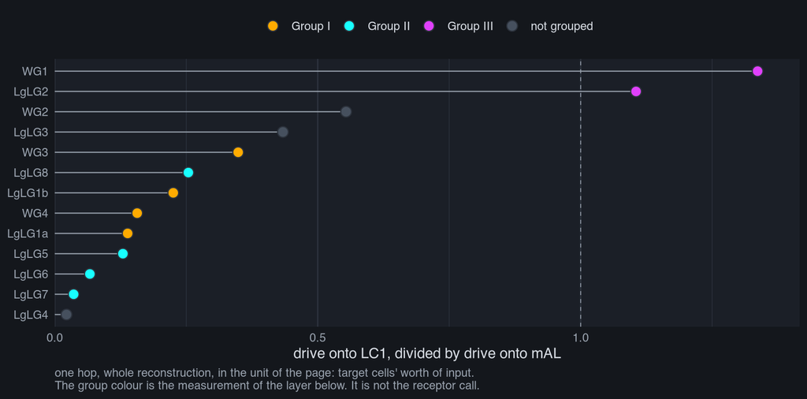

```r
arm_drive_plot(lr)
```

LgLG2, WG1 reach LC1 over the one hop route. The largest carrier of that path is AN05B102d, at a weight of 0.711. That carrier holds 84.1 percent of the path weight.

The LgLG5 and LgLG6 path onto mAL is spread over the AN09B017 family. The family holds 92.9 percent of that path weight. The three largest carriers are AN09B017a at 1.345, AN09B017f at 1.194 and AN09B017b at 0.620. No single carrier holds most of that path.

The two arms have different largest carriers.

The figure gives the LC1 drive divided by the mAL drive. WG1 gives 1.34 and LgLG2 gives 1.11. Only these two bristle types send more drive to LC1 than to mAL. The next type is WG2 at 0.55, and every other type is below that value.

LgLG2 and WG1 also drive mAL. mAL takes 0.29 of the whole dimorphic drive of LgLG2. It takes 0.26 of the whole dimorphic drive of WG1. Group III joins the convergence on mAL.

**The ratio separates Group III. Only Group III sends more drive to LC1 than to mAL.**

cVA is on the male cuticle. A male transfers cVA to the female at mating. A cVA node therefore labels a male or a mated female. A cVA node does not label the male sex.

## What the literature allows us to say

The mAL types take 37.4 percent of all the drive on this page. The sex label of mAL therefore changes the answer of the whole page.

Clowney EJ, Iguchi S, Bussell JJ, Scheer E, Ruta V, 2015, Neuron 87:1036-1049, PMID 26279475. The paper reports that mAL in the male responds to a male stimulus and to a female stimulus. It reports a stronger response to the female stimulus. The one purified compound that drives mAL is 7,11-heptacosadiene, and that compound is a female cuticular hydrocarbon. These names and numbers come from the paper.

Kallman BR, Kim H, Scott K, 2015, eLife 4:e11188, PMID 26568316. The paper reports that the M cells and the F cells both excite mAL. It also reports that mAL inhibits P1. These results come from the paper.

**mAL is not a male pheromone node.** A bristle type that drives mAL gets no sex label from that fact. The mAL share measures the size of a path. It does not measure the sex that the bristle detects.

## The answer at each layer

The page measures three layers. The answer is different at each layer.

Layer 1 is the bristles onto the ascending neurons. The 8 labelled types divide into two groups. The best split gives 0.970 and the worst gives 0.576. The receptor split has rank 19 of 35 at 0.722. The exact p value over the 35 enumerated splits is 0.54. Inside Group I the receptor split is the best of the three pairings at 0.727. Inside Group II the best pairing is LgLG5, LgLG6 against LgLG7, LgLG8 at 0.883, and it crosses the receptor split. Each nested test compares three pairings, so the best of three is not a significant result.

Layer 2 is the ascending neurons onto the dimorphic targets. The permutation test over the target profile gives a gap of -0.025 and a p value of 0.66 for the receptor split. mAL_m1 takes 10.69 percent of its input from AN09B017b and 5.64 percent from AN09B017g. Those two ascending types are on opposite sides inside Group II. The bootstrap gives the M set a support of 0.00. It gives the F set a support of 0.00. **A failure to separate is not a proof that the two streams carry the same information.**

Layer 3 is Group III. LgLG2, WG1 reach LC1 through AN05B102d. Their LC1 drive divided by their mAL drive is 1.11 and 1.34, and every other bristle type is below 0.55. Group III also drives mAL: mAL takes 0.29 and 0.26 of their whole dimorphic drive. The ratio separates Group III, and the target set does not.

The receptor assignment agrees with the connectome in one place. That place is Group I, at layer 1. The assignment does not order the whole set of 8 labelled types, and it does not order Group II.

The convergence at layer 2 is a limit of this measurement. Two streams that meet on one cell can still be two streams.

## What shape can and cannot do

```r
mn  <- morph_nblast(mba, types = setdiff(rownames(ts$m), "LgLG4"),
                    n_per_type = 4, seed = 1)
mr  <- morph_roi_cosine(mba, types = rownames(ts$m))
cnt <- morph_cell_counts(mba, groups = list(`Group I`   = quad,
                                            `Group II`  = five,
                                            `Group III` = b_set))

mn$confusion
```

| type | nearest | n | same_type |
| --- | --- | --- | --- |
| LgLG1a | LgLG1b | 2 | FALSE |
| LgLG1a | LgLG2 | 2 | FALSE |
| LgLG1b | LgLG1b | 2 | TRUE |
| LgLG1b | LgLG1a | 1 | FALSE |
| LgLG1b | LgLG2 | 1 | FALSE |
| LgLG2 | LgLG1a | 2 | FALSE |
| LgLG2 | LgLG2 | 2 | TRUE |
| LgLG3 | LgLG1b | 2 | FALSE |
| LgLG3 | LgLG3 | 2 | TRUE |
| LgLG5 | LgLG5 | 2 | TRUE |

[output cut: 18 more lines]

A reporter line labels a cell at the light level. The match of that cell to the reconstruction needs a property that light microscopy and the connectome both measure. This section measures whether shape is that property.

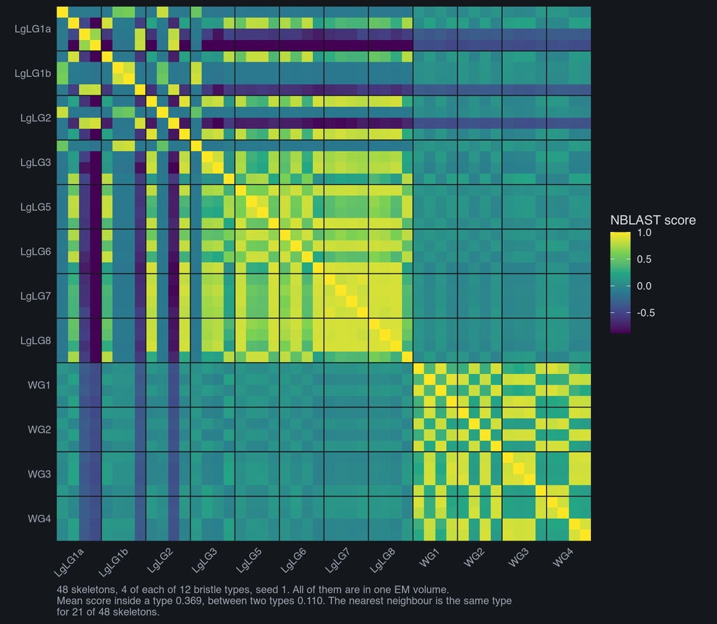

```r
morph_nblast_plot(mn)
```

NBLAST compares two skeletons. The page draws 4 cells of each of 12 bristle types, which is 48 skeletons. The draw uses the seed 1, so it is the same draw at every knit. LgLG4 is not in the set. All 48 skeletons are in one EM volume. The measurement therefore has no registration error.

The mean score inside a type is 0.369. The mean score between two types is 0.110. The nearest neighbour of a skeleton is a skeleton of the same type for 21 of 48 skeletons. The table above shows which type the measure names instead.

3 of the 12 types hold no skeleton that names its own type. They are LgLG1a, WG3, WG4.

Neuropil resolution is worse. The cosine over the presynapse volume profile is 0.75 to 1.000 inside Group I. It is 0.98 to 0.999 inside Group II. The receptor assignment separates LgLG1a from LgLG1b, and this profile gives them 0.999. It separates WG3 from WG4, and this profile gives them 1.000. It separates LgLG5 from LgLG8, and this profile gives them 0.999.

Cell count does separate Group II. Group II holds 64 cells, and 64 of them enter through T1. Group I holds 462 cells over T1, T2 and T3.

**Shape does not carry the identity of these bristle types. Light microscopy cannot supply the match by shape.** Cell count and neuromere can supply it.

## What would change this answer

The page measures one thing. It measures the target profile at one hop, in one connectome, in one male. Three measurements can separate the channels if the channels are separate.

The first is a physiological measurement. Select one bristle type. Apply male cuticular hydrocarbons, and then apply female cuticular hydrocarbons. Record the response. This measurement names the sex that the bristle detects, and no connectome measurement can do that.

The second is a measurement with an independent label. Express a reporter from the receptor gene. Match the labelled cells to the reconstruction by their cell count and by their neuromere, and not by their shape. The section above gives the reason. The present receptor assignment uses downstream partners, so it cannot test this page.

The third is a measurement that knows the sign of a path. Split each one hop path by the transmitter of the interneuron. Two bristle types can reach mAL_m1 through an excitatory path and through an inhibitory path. The present measure adds the two paths together, and it cannot see the sign.

## What this page does not show

The page does not show the sex that a bristle type detects. It shows which dimorphic neurons take the drive.

The one hop route is a model. The page counts two synapses and no more. A path of three synapses also exists, and this page does not measure it.

The page measures a convergence at layer 2. A convergence is not a proof that two streams carry the same information.

The interneuron layer keeps an interneuron at `min_frac` 0.005 of its whole input. The similarity is a property of that model.

The dimorphism annotation is incomplete. The page uses the four annotated classes, and it drops every neuron with no annotation.

The receptor identity of these bristle types is not settled. It is a light level call. The page tests it and does not adopt it.